# 01_01C_California_Housing_Model

### 캘리포니아 집값 - 추가 분석 2편 : 집값 예측 모델

### 학습 내용

- **선형 회귀 vs 랜덤포레스트 vs 그래디언트 부스팅**으로 집값을 예측하고 KFold 교차검증으로 비교하기
- `Pipeline`으로 **파생 변수 생성 → 스케일링 → 모델**을 하나로 묶고, 파생 변수의 효과를 측정하기
- 제공된 test 셋으로 최종 평가하고, **잔차 지도**로 모델이 어디서 틀리는지 확인하기

### 내용

- 0. 기본 분석 돌아보기 - 무엇을 보완할까?
- 1. 데이터 준비 - 파생 변수 함수와 Pipeline
- 2. 교차검증 전에 - 정렬된 데이터와 shuffle
- 3. 모델 비교 - 선형 회귀 / 랜덤포레스트 / 그래디언트 부스팅
- 4. 파생 변수 효과
- 5. test 셋으로 최종 평가
- 6. 변수 중요도
- 7. 잔차 분석 - 잔차 지도와 상한 절단
- 8. 정리

### 0. 기본 분석 돌아보기 - 무엇을 보완할까?

- 기본 분석([01_01_california](https://ldjwj.github.io/dataAnalysis/01_01_california.html)) : train 17,000행 / test 3,000행, 결측치 없음, 분포 확인까지 (모델 없음)
- 1편([01_01B_California_Housing_Map](https://ldjwj.github.io/dataAnalysis/01_01B_California_Housing_Map.html)) 에서 확인한 것
  - 집값과 상관이 가장 큰 변수 : 소득(0.69) > **해안 거리(-0.49)** > **대도시 거리(-0.44)** - 원래 위도(-0.15)·경도(-0.05)보다 강함
  - 가구당 방 수, 가구당 인원 같은 **비율 변수**가 합계 변수보다 관계가 뚜렷함
  - 집값은 **500,001달러에서 잘려 있음**(814개, 4.8%) → 비싼 지역에서는 예측이 어려울 것
- 이번 분석의 질문
  - 어떤 모델이 집값을 가장 잘 예측할까? 오차(RMSE)는 몇 달러 수준일까?
  - 1편의 파생 변수를 넣으면 성능이 실제로 좋아질까?

### 필수 라이브러리 불러오기

```python
import os
os.environ['OMP_NUM_THREADS'] = '2'   # 그래디언트 부스팅이 사용할 CPU 코어 수 제한

import pandas as pd
import numpy as np
import seaborn as sns
import matplotlib.pyplot as plt
import plotly.express as px
import plotly.io as pio
import time
import warnings
warnings.filterwarnings('ignore')

from sklearn.pipeline import Pipeline
from sklearn.preprocessing import FunctionTransformer, StandardScaler
from sklearn.linear_model import LinearRegression
from sklearn.ensemble import RandomForestRegressor, HistGradientBoostingRegressor
from sklearn.model_selection import KFold, cross_validate
from sklearn.metrics import mean_squared_error, r2_score, mean_absolute_error
from sklearn.inspection import permutation_importance
from sklearn.neighbors import BallTree

# plotly 그래프가 HTML 파일에 포함되도록 설정
pio.renderers.default = 'notebook'

# 한글 폰트 설정
# - koreanize-matplotlib이 설치되어 있으면 OS와 상관없이 나눔고딕을 사용 (pip install koreanize-matplotlib)
# - 없으면 OS에 맞는 기본 한글 폰트를 사용
try:
    import koreanize_matplotlib
except ImportError:
    import platform
    plt.rcParams['font.family'] = {'Windows': 'Malgun Gothic',
                                   'Darwin': 'AppleGothic'}.get(platform.system(), 'NanumGothic')
plt.rcParams['axes.unicode_minus'] = False

sns.set_theme(style='whitegrid', font=plt.rcParams['font.family'])
```

### 1. 데이터 준비 - 파생 변수 함수와 Pipeline

```python
train = pd.read_csv("./data/California/california_housing_train.csv")
test = pd.read_csv("./data/California/california_housing_test.csv")

target = 'median_house_value'
X_train, y_train = train.drop(columns=target), train[target]
X_test, y_test = test.drop(columns=target), test[target]
print(X_train.shape, X_test.shape)
```

```
(17000, 8) (3000, 8)
```

#### 파생 변수 함수 (1편과 동일한 방법)

- 비율 변수 : 가구당 방 수, 침실 비율, 가구당 인원(= 인구당 가구 수의 역수)
- 거리 변수 : LA·SF까지 거리, 가까운 대도시까지 거리, 근사 해안선까지 거리 (하버사인 공식, km)
- 해안 거리는 1편과 같은 근사 해안선을 쓰되, 가장 가까운 점을 `BallTree`로 빠르게 찾는다(교차검증에서 여러 번 계산하므로).
- 이 함수를 `FunctionTransformer`로 감싸면 Pipeline 안에서 **train/test에 똑같이** 적용된다.

```python
def haversine(lat1, lon1, lat2, lon2):
    # 위도/경도(도) → 거리(km)
    lat1, lon1, lat2, lon2 = map(np.radians, [lat1, lon1, lat2, lon2])
    a = np.sin((lat2 - lat1) / 2)**2 + np.cos(lat1) * np.cos(lat2) * np.sin((lon2 - lon1) / 2)**2
    return 6371 * 2 * np.arcsin(np.sqrt(a))

CITIES = {'LA': (34.05, -118.24), 'SF': (37.77, -122.42)}
COAST = np.array([   # 근사 해안선 (북 → 남, 위도, 경도)
    (41.75, -124.20), (40.80, -124.16), (40.44, -124.40), (39.45, -123.80),
    (38.91, -123.71), (38.33, -123.05), (38.00, -123.00), (37.76, -122.51),
    (37.46, -122.44), (36.96, -122.02), (36.60, -121.89), (36.27, -121.81),
    (35.64, -121.19), (35.37, -120.85), (34.45, -120.47), (34.41, -119.69),
    (34.27, -119.29), (34.03, -118.78), (34.01, -118.50), (33.76, -118.19),
    (33.60, -117.90), (33.19, -117.38), (32.72, -117.17), (32.58, -117.13)])
coast_pts = np.vstack([np.linspace(COAST[i], COAST[i + 1], 100) for i in range(len(COAST) - 1)])
# 가장 가까운 해안선 점을 빠르게 찾기 위한 BallTree (하버사인 거리, 라디안 단위)
coast_tree = BallTree(np.radians(coast_pts), metric='haversine')

RATIO_COLS = ['rooms_per_household', 'bedrooms_per_room', 'population_per_household']
DIST_COLS = ['dist_LA', 'dist_SF', 'dist_city', 'dist_coast']

def add_features(X, ratio=True, dist=True, clip=False):
    X = X.copy()
    if ratio:
        X['rooms_per_household'] = X['total_rooms'] / X['households']
        X['bedrooms_per_room'] = X['total_bedrooms'] / X['total_rooms']
        X['population_per_household'] = X['population'] / X['households']
        if clip:   # 이상치 자르기 (4장에서 사용)
            X['rooms_per_household'] = X['rooms_per_household'].clip(upper=10)
            X['population_per_household'] = X['population_per_household'].clip(upper=6)
    if dist:
        for name, (lat, lon) in CITIES.items():
            X[f'dist_{name}'] = haversine(X['latitude'], X['longitude'], lat, lon)
        X['dist_city'] = X[['dist_LA', 'dist_SF']].min(axis=1)
        d, _ = coast_tree.query(np.radians(X[['latitude', 'longitude']].values))
        X['dist_coast'] = d[:, 0] * 6371   # 라디안 → km
    return X

add_features(X_train).iloc[:3, 8:].round(2)
```

|  | rooms_per_household | bedrooms_per_room | population_per_household | dist_LA | dist_SF | dist_city | dist_coast |
| --- | --- | --- | --- | --- | --- | --- | --- |
| 0 | 11.89 | 0.23 | 2.15 | 362.09 | 830.81 | 362.09 | 305.01 |
| 1 | 16.52 | 0.25 | 2.44 | 348.77 | 806.30 | 348.77 | 300.67 |
| 2 | 6.15 | 0.24 | 2.85 | 342.09 | 841.65 | 342.09 | 265.02 |

- 한줄 확인 : 원래 8개 변수에 비율 3개 + 거리 4개, 총 **15개 변수**가 된다.

#### Pipeline 만들기

- `Pipeline([('features', ...), ('scaler', ...), ('model', ...)])` : 순서대로 실행되는 하나의 모델
- 선형 회귀는 변수 단위(달러, km, 명)가 달라서 **표준화(StandardScaler)** 를 넣는다. 트리 모델은 스케일링이 필요 없다.

```python
def make_pipe(model, ratio=True, dist=True, scale=False, clip=False):
    steps = [('features', FunctionTransformer(add_features,
                                              kw_args={'ratio': ratio, 'dist': dist, 'clip': clip}))]
    if scale:
        steps.append(('scaler', StandardScaler()))
    steps.append(('model', model))
    return Pipeline(steps)

MODELS = {
    '선형 회귀': (LinearRegression(), True),
    '랜덤포레스트': (RandomForestRegressor(n_estimators=100, max_features=0.5, n_jobs=2, random_state=42), False),
    '그래디언트 부스팅': (HistGradientBoostingRegressor(max_iter=300, random_state=42), False),
}
make_pipe(*MODELS['선형 회귀'][:1], scale=True)
```

```
Pipeline(steps=[('features',
                 FunctionTransformer(func=<function add_features at 0x7fb2f38fef20>,
                                     kw_args={'clip': False, 'dist': True,
                                              'ratio': True})),
                ('scaler', StandardScaler()), ('model', LinearRegression())])
```

### 2. 교차검증 전에 - 정렬된 데이터와 shuffle

- 1편에서 train 데이터가 **경도 순서로 정렬**되어 있는 것을 봤다.
- `KFold(shuffle=False)`로 나누면 첫 번째 폴드는 '동쪽 지역만', 마지막 폴드는 '서쪽 지역만' 검증하게 된다.

```python
scoring = {'rmse': 'neg_root_mean_squared_error', 'r2': 'r2'}
lr_pipe = make_pipe(LinearRegression(), scale=True)

for shuffle in [False, True]:
    kf = KFold(n_splits=5, shuffle=shuffle, random_state=42 if shuffle else None)
    res = cross_validate(lr_pipe, X_train, y_train, cv=kf, scoring=scoring)
    print(f'shuffle={shuffle!s:5} | 폴드별 R²:', np.round(res['test_r2'], 3),
          f'| 평균 RMSE {-res["test_rmse"].mean():,.0f}')
```

```
shuffle=False | 폴드별 R²: [0.55  0.505 0.624 0.233 0.509] | 평균 RMSE 77,180
```

```
shuffle=True  | 폴드별 R²: [0.677 0.662 0.521 0.676 0.611] | 평균 RMSE 70,345
```

- 한줄 확인 : shuffle 없이 나누면 폴드별 R²가 **0.233 ~ 0.624**로 크게 흔들리고(4번째 폴드 0.233), 평균 RMSE도 77,180달러로 나쁘다. 섞어서 나누면 R² 0.521 ~ 0.677, RMSE 70,345달러
  - 정렬된 데이터를 그대로 자르면 '학습하지 않은 지역'을 예측하게 되어 성능이 잘못 평가된다.
  - 이후 모든 교차검증은 `KFold(n_splits=5, shuffle=True, random_state=42)`를 사용한다.

### 3. 모델 비교 - 선형 회귀 / 랜덤포레스트 / 그래디언트 부스팅

- 기준선(baseline) : 모든 집을 **train 평균값으로 예측**했을 때의 RMSE = 집값의 표준편차
- 각 모델을 **원래 변수 8개** / **파생 변수 포함 15개**로 5-폴드 교차검증한다.

```python
kf = KFold(n_splits=5, shuffle=True, random_state=42)
print(f'기준선 RMSE (평균으로 예측) : {y_train.std(ddof=0):,.0f}달러')

rows = []
for name, (model, scale) in MODELS.items():
    for feat_name, use in [('원래 8개', False), ('파생 포함 15개', True)]:
        start = time.time()
        pipe = make_pipe(model, ratio=use, dist=use, scale=scale)
        res = cross_validate(pipe, X_train, y_train, cv=kf, scoring=scoring)
        rows.append({'모델': name, '변수': feat_name,
                     'RMSE 평균': -res['test_rmse'].mean(), 'RMSE 표준편차': res['test_rmse'].std(),
                     'R² 평균': res['test_r2'].mean(), '시간(초)': time.time() - start})
cv_tbl = pd.DataFrame(rows)
cv_tbl.round({'RMSE 평균': 0, 'RMSE 표준편차': 0, 'R² 평균': 3, '시간(초)': 1})
```

```
기준선 RMSE (평균으로 예측) : 115,980달러
```

|  | 모델 | 변수 | RMSE 평균 | RMSE 표준편차 | R² 평균 | 시간(초) |
| --- | --- | --- | --- | --- | --- | --- |
| 0 | 선형 회귀 | 원래 8개 | 69785.0 | 1825.0 | 0.637 | 0.1 |
| 1 | 선형 회귀 | 파생 포함 15개 | 70345.0 | 5114.0 | 0.629 | 0.8 |
| 2 | 랜덤포레스트 | 원래 8개 | 48865.0 | 847.0 | 0.822 | 10.7 |
| 3 | 랜덤포레스트 | 파생 포함 15개 | 44394.0 | 531.0 | 0.853 | 18.1 |
| 4 | 그래디언트 부스팅 | 원래 8개 | 46592.0 | 837.0 | 0.838 | 3.3 |
| 5 | 그래디언트 부스팅 | 파생 포함 15개 | 44191.0 | 524.0 | 0.855 | 3.7 |

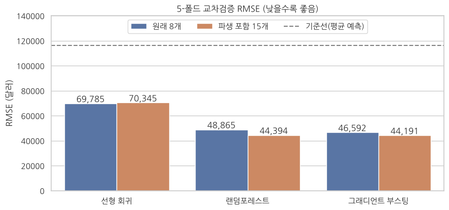

```python
fig, ax = plt.subplots(figsize=(10, 4.5))
sns.barplot(data=cv_tbl, x='모델', y='RMSE 평균', hue='변수', ax=ax)
for c in ax.containers:
    ax.bar_label(c, fmt='{:,.0f}')
ax.axhline(y_train.std(ddof=0), color='gray', ls='--', label='기준선(평균 예측)')
ax.set_title('5-폴드 교차검증 RMSE (낮을수록 좋음)')
ax.set_ylabel('RMSE (달러)'); ax.set_xlabel('')
ax.set_ylim(0, 140000)
ax.legend(loc='upper center', ncol=3)
plt.show()
```

- 한줄 확인 : 평균으로만 예측하면 RMSE 115,980달러. 선형 회귀는 약 **7만 달러(R² 0.637)**, 트리 모델은 **4.4만 달러대(R² 0.85)** 로 크게 좋다.
  - 가장 좋은 조합은 **그래디언트 부스팅 + 파생 변수 15개 (RMSE 44,191, R² 0.855)**, 랜덤포레스트(44,394)도 거의 같다.
  - 파생 변수 효과 : 랜덤포레스트 48,865 → 44,394 (**9.1% 감소**), 그래디언트 부스팅 46,592 → 44,191 (**5.2% 감소**)
  - 그런데 선형 회귀는 오히려 69,785 → 70,345로 나빠졌고 폴드 간 표준편차도 1,825 → 5,114로 커졌다. → 4장에서 원인 확인

### 4. 파생 변수 효과 - 어떤 변수 묶음이 도움이 될까?

- 비율 변수만 추가 / 거리 변수만 추가 / 둘 다 추가로 나누어 효과를 본다.
- 시간을 줄이기 위해 빠른 두 모델(선형 회귀, 그래디언트 부스팅)로 비교한다.

```python
combos = {'원래 8개': (False, False), '+ 비율 3개': (True, False),
          '+ 거리 4개': (False, True), '+ 비율 + 거리': (True, True)}
rows = []
for name in ['선형 회귀', '그래디언트 부스팅']:
    model, scale = MODELS[name]
    for combo, (ratio, dist) in combos.items():
        res = cross_validate(make_pipe(model, ratio, dist, scale), X_train, y_train,
                             cv=kf, scoring=scoring)
        rows.append({'모델': name, '변수': combo, 'RMSE': -res['test_rmse'].mean(), 'R²': res['test_r2'].mean()})
abl = pd.DataFrame(rows)
abl_rmse = abl.pivot(index='변수', columns='모델', values='RMSE').loc[list(combos)]
abl_r2 = abl.pivot(index='변수', columns='모델', values='R²').loc[list(combos)]
pd.concat({'RMSE': abl_rmse.round(0), 'R²': abl_r2.round(3)}, axis=1)
```

| 모델 변수 | RMSE 그래디언트 부스팅 | RMSE 선형 회귀 | R² 그래디언트 부스팅 | R² 선형 회귀 |
| --- | --- | --- | --- | --- |
| 원래 8개 | 46592.0 | 69785.0 | 0.838 | 0.637 |
| + 비율 3개 | 45690.0 | 70925.0 | 0.845 | 0.624 |
| + 거리 4개 | 44937.0 | 68744.0 | 0.850 | 0.648 |
| + 비율 + 거리 | 44191.0 | 70345.0 | 0.855 | 0.629 |

- 한줄 확인 : 그래디언트 부스팅은 비율 변수(46,592 → 45,690)와 거리 변수(→ 44,937) **모두 도움**이 되고, 거리 변수의 효과가 더 크다. 둘 다 넣을 때 가장 좋다(44,191).
  - 선형 회귀는 거리 변수만 넣으면 좋아지지만(68,744), 비율 변수를 넣으면 나빠진다(70,925).

#### 선형 회귀는 왜 비율 변수를 넣으면 나빠질까? - 이상치

- 1편에서 가구당 방 수 최댓값은 141.9개, 가구당 인원 최댓값은 502.5명이었다.
- 선형 회귀는 직선(평면)으로 맞추기 때문에 이런 극단값 몇 개에 계수가 크게 흔들린다. 폴드별 RMSE를 보면 확인할 수 있다.
- 해결 : 가구당 방 수는 **10개**, 가구당 인원은 **6명**에서 자른다(clip). 트리 모델은 값의 순서만 보므로 이상치 영향이 작다.

```python
X_ratio = add_features(X_train, dist=False)
print('가구당 방 > 10 :', (X_ratio['rooms_per_household'] > 10).sum(), '개,',
      '가구당 인원 > 6 :', (X_ratio['population_per_household'] > 6).sum(), '개')

lr = MODELS['선형 회귀'][0]
for clip in [False, True]:
    res = cross_validate(make_pipe(lr, scale=True, clip=clip), X_train, y_train, cv=kf, scoring=scoring)
    print(f'clip={clip!s:5} | 폴드별 RMSE:', np.round(-res['test_rmse']).astype(int),
          f'| 평균 {-res["test_rmse"].mean():,.0f}, R² {res["test_r2"].mean():.3f}')
```

```
가구당 방 > 10 : 182 개, 가구당 인원 > 6 : 90 개
```

```
clip=False | 폴드별 RMSE: [66673 67379 79775 66150 71750] | 평균 70,345, R² 0.629
```

```
clip=True  | 폴드별 RMSE: [64949 65404 65978 64075 67190] | 평균 65,519, R² 0.681
```

- 한줄 확인 : 자르기 전에는 3번째 폴드만 RMSE **79,775**로 튀었다(나머지 66,150 ~ 71,750). 극단값 블록이 들어간 폴드에서 선형 회귀가 크게 틀린 것
  - 가구당 방 > 10(182개), 가구당 인원 > 6(90개)을 자르니 모든 폴드가 64,075 ~ 67,190으로 안정되고, 평균 **65,519 (R² 0.681)** 로 원래 8개 변수(69,785)보다 **6.1% 좋아졌다.**

### 5. test 셋으로 최종 평가

- 교차검증으로 모델과 변수(파생 포함 15개, 선형 회귀는 이상치 자르기)를 정한 뒤, **train 전체로 다시 학습**하고 한 번도 사용하지 않은 **test 3,000개**로 평가한다.

```python
# 선형 회귀는 이상치를 자른 버전으로 평가
FINAL = {'선형 회귀(clip)': (LinearRegression(), True, True),
         '랜덤포레스트': (*MODELS['랜덤포레스트'], False),
         '그래디언트 부스팅': (*MODELS['그래디언트 부스팅'], False)}
final = {}
rows = []
for name, (model, scale, clip) in FINAL.items():
    pipe = make_pipe(model, scale=scale, clip=clip).fit(X_train, y_train)
    pred = pipe.predict(X_test)
    final[name] = (pipe, pred)
    rows.append({'모델': name,
                 'RMSE': np.sqrt(mean_squared_error(y_test, pred)),
                 'MAE': mean_absolute_error(y_test, pred),
                 'R²': r2_score(y_test, pred)})
test_tbl = pd.DataFrame(rows).set_index('모델')
test_tbl.round({'RMSE': 0, 'MAE': 0, 'R²': 3})
```

| 모델 | RMSE | MAE | R² |
| --- | --- | --- | --- |
| 선형 회귀(clip) | 66267.0 | 47495.0 | 0.657 |
| 랜덤포레스트 | 45096.0 | 28419.0 | 0.841 |
| 그래디언트 부스팅 | 45591.0 | 28970.0 | 0.838 |

- 한줄 확인 : test 셋에서는 **랜덤포레스트 RMSE 45,096 (R² 0.841)**, 그래디언트 부스팅 45,591 (R² 0.838), 선형 회귀(clip) 66,267 (R² 0.657)
  - 교차검증(그래디언트 부스팅 44,191)과 test 결과가 비슷하다 → 과대적합 없이 새 데이터에도 비슷한 성능
  - 두 트리 모델의 차이는 495달러(약 1%)로, CV와 test에서 순위가 바뀔 만큼 **사실상 같은 수준**이다.
  - MAE 약 2.8~2.9만 달러 : 트리 모델은 블록 집값을 평균 3만 달러 정도 차이로 예측한다.

### 6. 변수 중요도 - 무엇이 집값을 결정할까?

- **순열 중요도(permutation importance)** : 한 변수의 값을 무작위로 섞었을 때 test 점수(R²)가 얼마나 떨어지는지 측정한다.
  - 많이 떨어질수록 모델이 그 변수에 크게 의존한다는 뜻. 모델 종류와 상관없이 같은 방법으로 비교할 수 있다.
- 교차검증에서 가장 좋았던 그래디언트 부스팅으로 확인한다.

```python
r = permutation_importance(final['그래디언트 부스팅'][0], X_test, y_test, n_repeats=5,
                           random_state=42, scoring='r2')
imp8 = pd.Series(r.importances_mean, index=X_test.columns).sort_values(ascending=False)
imp8.round(3).to_frame('R² 감소량 (입력 변수 8개)')
```

|  | R² 감소량 (입력 변수 8개) |
| --- | --- |
| latitude | 0.760 |
| longitude | 0.737 |
| total_rooms | 0.396 |
| median_income | 0.291 |
| population | 0.189 |
| households | 0.116 |
| total_bedrooms | 0.066 |
| housing_median_age | 0.035 |

- 순열 중요도는 **입력 변수(원래 8개)** 단위로 계산된다. 파생 변수는 Pipeline 안에서 만들어지므로, 예를 들어 `latitude`를 섞으면 위도로 계산한 거리 변수까지 함께 망가진다.
- 그래서 파생 변수 자체의 중요도는 Pipeline에서 꺼낸 **모델 안의 15개 변수**로 따로 확인한다.

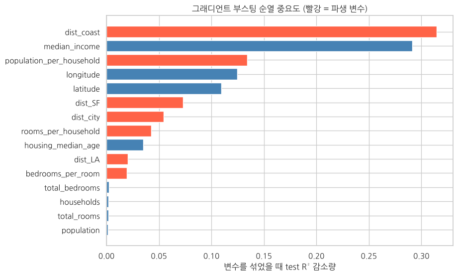

```
dist_coast                  0.315
median_income               0.291
population_per_household    0.134
longitude                   0.125
latitude                    0.109
dist_SF                     0.073
dist_city                   0.054
rooms_per_household         0.043
dtype: float64
```

```python
# Pipeline의 앞 단계(features)만 적용해서 15개 변수 데이터 만들기
X_test_feat = final['그래디언트 부스팅'][0].named_steps['features'].transform(X_test)
gb_model = final['그래디언트 부스팅'][0].named_steps['model']
r = permutation_importance(gb_model, X_test_feat, y_test, n_repeats=5, random_state=42, scoring='r2')
imp15 = pd.Series(r.importances_mean, index=X_test_feat.columns).sort_values()

fig, ax = plt.subplots(figsize=(9, 6))
colors = ['tomato' if c in RATIO_COLS + DIST_COLS else 'steelblue' for c in imp15.index]
ax.barh(imp15.index, imp15.values, color=colors)
ax.set_title('그래디언트 부스팅 순열 중요도 (빨강 = 파생 변수)')
ax.set_xlabel('변수를 섞었을 때 test R² 감소량')
plt.show()
imp15.sort_values(ascending=False).round(3).head(8)
```

- 한줄 확인 : 15개 변수 기준으로 **해안 거리(dist_coast, 0.315)** 가 소득(0.291)보다도 중요하고, 3위도 파생 변수인 **가구당 인원(0.134)** 이다.
  - 반대로 합계 변수(`total_rooms`, `population`, `households`, `total_bedrooms`)는 거의 0 → 비율 변수가 그 역할을 대신한다.
  - 입력 8개 기준에서는 위도(0.760)·경도(0.737)가 1, 2위였다. 위도·경도를 섞으면 거리 변수 4개가 함께 망가지기 때문. `total_rooms`(0.396)가 소득(0.291)보다 높은 것도 비율 변수 2개에 쓰이기 때문이다.

### 7. 잔차 분석 - 모델은 어디서 틀릴까?

- 잔차 = 실제값 - 예측값. **양수면 모델이 낮게(과소) 예측**, 음수면 높게(과대) 예측한 것

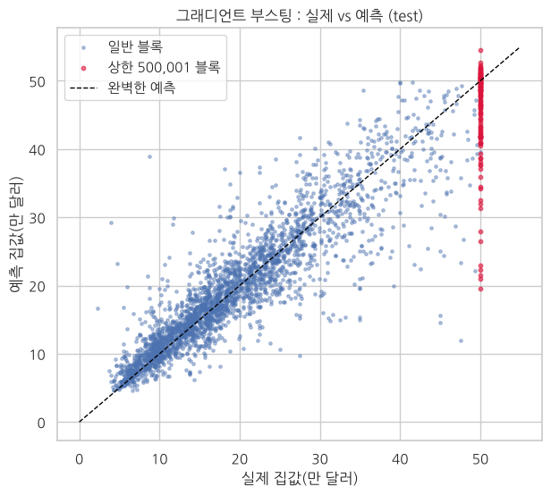

```python
res_df = test.copy()
res_df['예측'] = final['그래디언트 부스팅'][1]
res_df['잔차'] = res_df[target] - res_df['예측']
res_df['상한'] = res_df[target] == 500001
res_df['잔차_만'] = res_df['잔차'] / 10000
res_df['dist_coast'] = add_features(X_test, ratio=False)['dist_coast']

fig, ax = plt.subplots(figsize=(7, 6))
ax.scatter(res_df.loc[~res_df['상한'], target] / 1e4, res_df.loc[~res_df['상한'], '예측'] / 1e4,
           s=6, alpha=0.4, label='일반 블록')
ax.scatter(res_df.loc[res_df['상한'], target] / 1e4, res_df.loc[res_df['상한'], '예측'] / 1e4,
           s=10, color='crimson', alpha=0.6, label='상한 500,001 블록')
ax.plot([0, 55], [0, 55], color='black', ls='--', lw=1, label='완벽한 예측')
ax.set_xlabel('실제 집값(만 달러)'); ax.set_ylabel('예측 집값(만 달러)')
ax.set_title('그래디언트 부스팅 : 실제 vs 예측 (test)')
ax.legend()
plt.show()
```

```python
# 상한 블록과 일반 블록의 오차 비교
grp = res_df.groupby('상한').apply(lambda g: pd.Series({
    '블록수': len(g),
    'RMSE': np.sqrt((g['잔차']**2).mean()),
    '잔차 평균': g['잔차'].mean()}), include_groups=False)
grp.index = grp.index.map({False: '일반 블록', True: '상한 블록'})
grp.round(0)
```

| 상한 | 블록수 | RMSE | 잔차 평균 |
| --- | --- | --- | --- |
| 일반 블록 | 2875.0 | 42861.0 | -1707.0 |
| 상한 블록 | 125.0 | 87369.0 | 48676.0 |

- 한줄 확인 : test의 상한 블록 125개는 RMSE **87,369달러**로 일반 블록(42,861)의 약 2배이고, 잔차 평균이 **+48,676달러** → 체계적으로 낮게 예측한다.
  - 그림에서도 실제값 50만 달러 위치에 빨간 점이 세로로 길게(예측 약 20만~54만 달러) 퍼져 있다.
  - 실제 집값은 500,001달러 **이상**이므로, 진짜 오차는 이보다 더 클 수 있다.

#### 잔차 지도 - matplotlib

- 빨강 = 실제보다 낮게 예측(과소), 파랑 = 실제보다 높게 예측(과대). 색 범위는 ±10만 달러로 고정

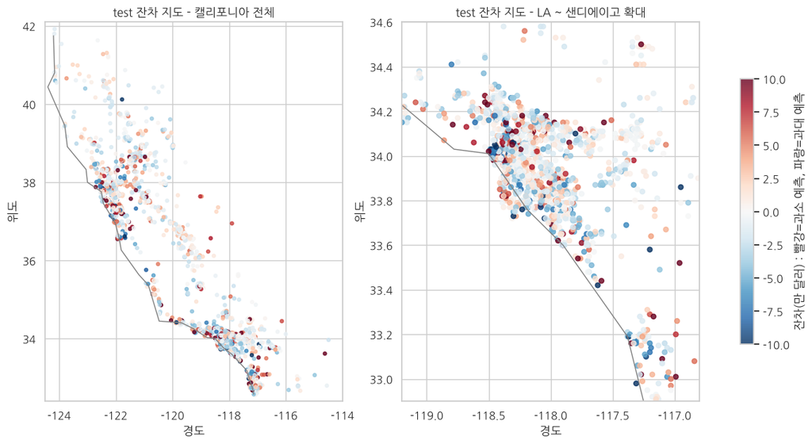

```python
fig, axes = plt.subplots(1, 2, figsize=(15, 7))
for ax, (lon_rng, lat_rng, title) in zip(axes, [((-124.5, -114), (32.4, 42.1), '캘리포니아 전체'),
                                                ((-119.2, -116.8), (32.9, 34.6), 'LA ~ 샌디에이고 확대')]):
    sc = ax.scatter(res_df['longitude'], res_df['latitude'], c=res_df['잔차_만'], cmap='RdBu_r',
                    vmin=-10, vmax=10, s=12 if ax is axes[0] else 25, alpha=0.8)
    ax.plot(COAST[:, 1], COAST[:, 0], color='gray', lw=1)
    ax.set_xlim(lon_rng); ax.set_ylim(lat_rng)
    ax.set_title(f'test 잔차 지도 - {title}')
    ax.set_xlabel('경도'); ax.set_ylabel('위도')
fig.colorbar(sc, ax=axes, shrink=0.7, label='잔차(만 달러) : 빨강=과소 예측, 파랑=과대 예측')
plt.show()
```

```python
# 해안 거리 구간별 오차
res_df['coast_band'] = pd.cut(res_df['dist_coast'], [0, 10, 25, 50, 100, 500],
                              labels=['0~10', '10~25', '25~50', '50~100', '100~500'], include_lowest=True)
res_df.groupby('coast_band', observed=True).agg(
    블록수=('잔차', 'size'),
    RMSE=('잔차', lambda s: np.sqrt((s**2).mean())),
    절대잔차_중앙값=('잔차', lambda s: s.abs().median()),
    상한비율=('상한', 'mean')).round({'RMSE': 0, '절대잔차_중앙값': 0, '상한비율': 3})
```

| coast_band | 블록수 | RMSE | 절대잔차_중앙값 | 상한비율 |
| --- | --- | --- | --- | --- |
| 0~10 | 672 | 57462.0 | 25241.0 | 0.088 |
| 10~25 | 826 | 45138.0 | 18585.0 | 0.062 |
| 25~50 | 608 | 45486.0 | 20020.0 | 0.025 |
| 50~100 | 270 | 36222.0 | 14568.0 | 0.000 |
| 100~500 | 624 | 34006.0 | 13105.0 | 0.000 |

- 한줄 확인 : 해안 10km 이내 RMSE **57,462달러** → 100km 이상 **34,006달러**. 해안에 가까울수록 오차가 크다(절대잔차 중앙값도 25,241 → 13,105).
  - 해안 지역은 집값 자체가 높고 상한 블록 비율(8.8%)도 높아서 오차가 커진다. 지도에서도 LA 해안 근처에 진한 빨강·파랑 점이 섞여 있다.

#### 잔차 지도 - plotly (인터랙티브)

- test 3,000개 전체를 표시한다. 마우스를 올리면 실제값·예측값·잔차를 볼 수 있다.

```python
plot_df = res_df.assign(실제_만=res_df[target] / 1e4, 예측_만=res_df['예측'] / 1e4)
fig = px.scatter_map(plot_df, lat='latitude', lon='longitude', color='잔차_만',
                     color_continuous_scale='RdBu_r', range_color=[-10, 10],
                     hover_data={'실제_만': ':.1f', '예측_만': ':.1f', '잔차_만': ':.1f',
                                 'latitude': False, 'longitude': False},
                     zoom=4.8, center={'lat': 36.8, 'lon': -119.4},
                     map_style='carto-positron', height=650,
                     title='그래디언트 부스팅 test 잔차 지도 (단위: 만 달러, 빨강 = 과소 예측)')
fig.update_traces(marker=dict(size=6, opacity=0.8))
fig.update_layout(margin=dict(l=0, r=0, t=40, b=0))
fig.show()
```

[interactive chart not shown]

### 8. 정리

| 질문 | 기본 분석 | 추가 분석 결과 |
| --- | --- | --- |
| 교차검증은 어떻게? | - | train이 경도 순 정렬 → `shuffle=True` 필수 (shuffle 없으면 폴드 R² 0.233까지 하락) |
| 어떤 모델이 좋은가? | 모델 없음 | 트리 모델 : 그래디언트 부스팅 CV RMSE 44,191 (R² 0.855) ≈ 랜덤포레스트 44,394. 선형 회귀는 약 6.6~7만 달러 |
| 파생 변수 효과는? | - | 랜덤포레스트 9.1%, 그래디언트 부스팅 5.2% RMSE 감소. 선형 회귀는 비율 변수 **이상치를 자른 뒤** 6.1% 개선 |
| test 최종 성능은? | - | 랜덤포레스트 RMSE 45,096 (R² 0.841), 그래디언트 부스팅 45,591 (R² 0.838), 선형 회귀 66,267 (R² 0.657) |
| 무엇이 가장 중요한가? | - | 해안 거리(0.315) ≈ 소득(0.291) > 가구당 인원(0.134). 합계 변수는 거의 0 |
| 어디서 틀리는가? | - | 상한 블록(RMSE 87,369, 평균 4.9만 달러 과소 예측), 해안 10km 이내(RMSE 57,462) |

#### 배운 점

- 데이터가 정렬되어 있으면 `KFold(shuffle=True)`가 필수 - 확인하지 않으면 성능을 잘못 평가한다.
- `Pipeline` + `FunctionTransformer`로 파생 변수 생성까지 묶으면 train/test에 같은 처리가 보장된다.
- 도메인 지식으로 만든 변수(해안·대도시 거리, 가구당 비율)는 트리 모델의 성능을 5~9% 끌어올린다. 다만 선형 회귀는 **이상치 처리**를 함께 해야 효과가 난다.
- 전체 점수(R²)만 보지 말고 **잔차를 지도/그룹별로** 보면 모델의 약점(상한 절단, 비싼 해안 지역)이 드러난다.

#### 다음에 해 볼 분석

- 집값에 **로그 변환**을 하거나, 상한 블록을 따로 다루는 방법(제외, 분류+회귀) 비교
- 그래디언트 부스팅 하이퍼파라미터 튜닝(`learning_rate`, `max_leaf_nodes`), 다른 대도시(샌디에이고, 새크라멘토) 거리 추가